# Hierarchical Models

Matthew Talluto

02.12.2021

# Temperature-mortality relationships in Tsuga

- We return to the mortality of trees in North American forests
- The dataset contains information for multiple species and years
  - there is replication within units
- For now, we focus on *Tsuga canadensis*

```r
trees = fread("exercises/data/treedata.csv")
tsuga = trees[grep("Tsuga", species_name)]
head(tsuga)
```

```
##    n died year     species_name annual_mean_temp tot_annual_pp   prior_mu
## 1: 5    3 1989 Tsuga canadensis         3.849333     1003.0000 0.02222166
## 2: 6    0 1989 Tsuga canadensis         3.452000     1076.1333 0.02222166
## 3: 3    0 1997 Tsuga canadensis         3.620000     1099.4000 0.03245619
## 4: 4    4 1989 Tsuga canadensis         4.596000      989.4667 0.02222166
## 5: 3    0 1994 Tsuga canadensis         4.244667     1116.2000 0.02816339
## 6: 7    0 2002 Tsuga canadensis         4.730000     1137.2667 0.04108793
```

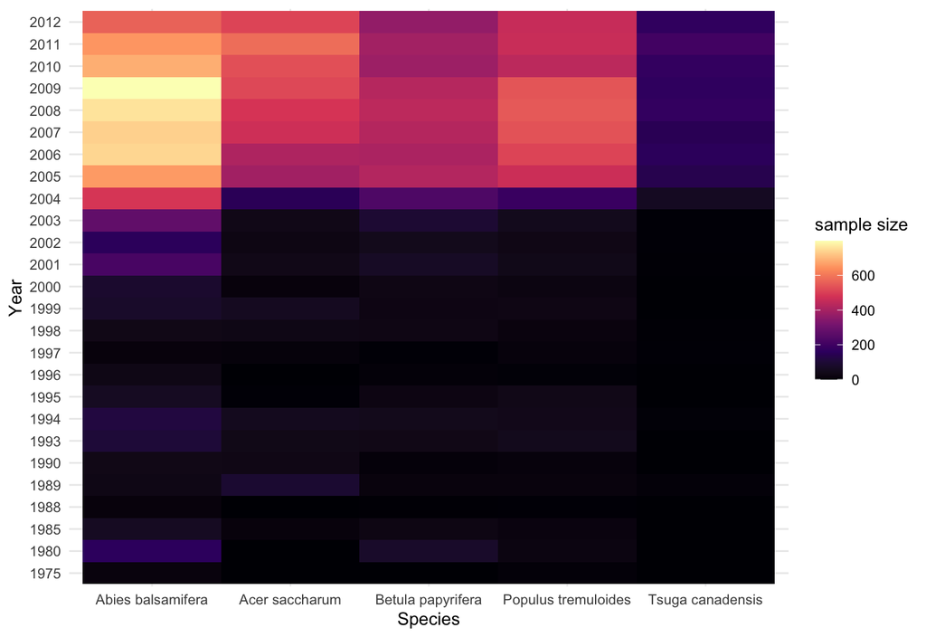

# Temperature-mortality relationships in Tsuga: H1

- We return to the mortality of trees in North American forests
- The dataset contains information for multiple species and years
- For now, we focus on *Tsuga canadensis*
- **Hypothesis 1**: The temperature-mortality relationship is the same across all years (**Complete pooling**, 2 params)

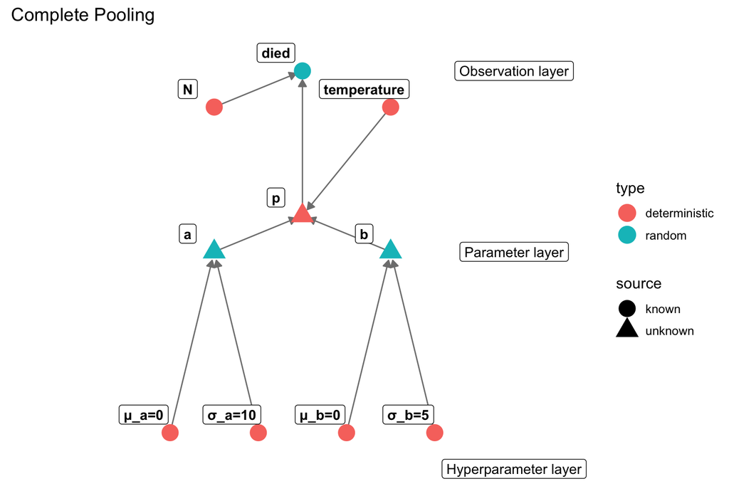

# Temperature-mortality relationships in Tsuga: H2

- We return to the mortality of trees in North American forests
- The dataset contains information for multiple species and years
- For now, we focus on *Tsuga canadensis*
- **Hypothesis 1**: The temperature-mortality relationship is the same across all years (**Complete pooling**, 2 params)
- **Hypothesis 2**: The *average survival* varies by year, but the slope between temperature and mortality is constant (**Unpooled intercepts, pooled slopes**, 17 params)
  - Sample size by year ranges from 1 to 208

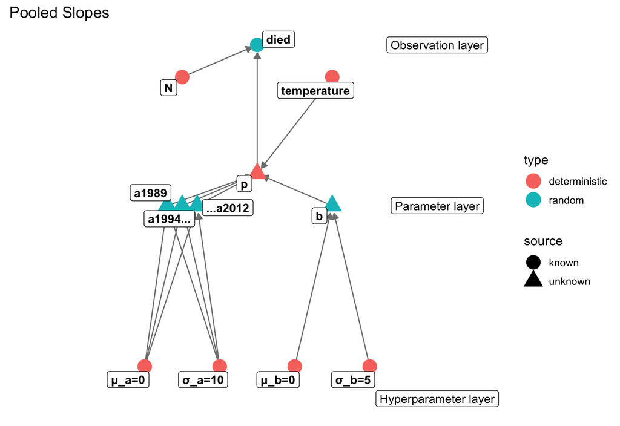

# Temperature-mortality relationships in Tsuga: H3

- We return to the mortality of trees in North American forests
- The dataset contains information for multiple species and years
- For now, we focus on *Tsuga canadensis*
- **Hypothesis 1**: The temperature-mortality relationship is the same across all years (**Complete pooling**, 2 params)
- **Hypothesis 2**: The *average survival* varies by year, but the slope between temperature and mortality is constant (**Unpooled intercepts, pooled slopes**, 17 params)
  - Sample size by year ranges from 1 to 208
- **Hypothesis 3**: There is a different regression line for each year (**No pooling**, 32 parameters)

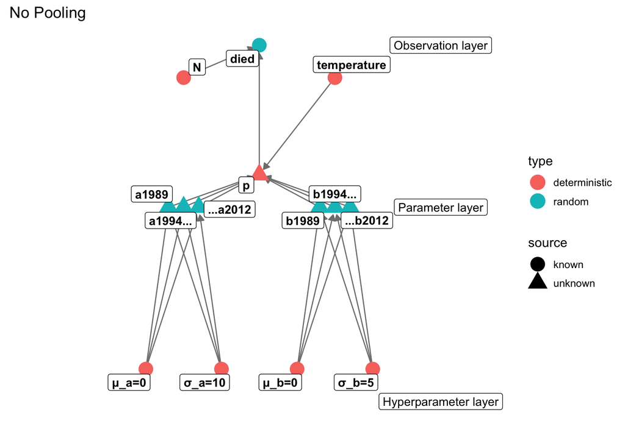

# Pooled models trade accuracy for precision

- All data for a single set of estimates
- High prediction errors for individual groups
- Groups with small samples biased towards the mean

```r
temperature = scale(tsuga$annual_mean_temp) ## note that I have rescaled temperature
standat = with(tsuga, list(
    n = length(died),
    n_trees = n,
    died = died,
    temperature = temperature[,1]))
fit_h1 = sampling(tsuga_h1, chains=4, iter=3000, refresh=0, data = standat)
```

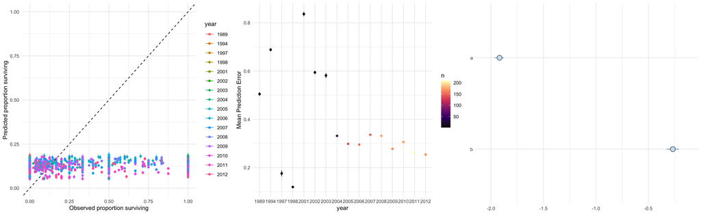

# Unpooled models use less data per parameter

```stan
data {
  // number of data points
    int <lower=0> n;

    // response
    // number of trees in each plot
    int <lower=1> n_trees [n];
  // number died
    int <lower=0> died [n];

    // predictors
    vector [n] temperature;

    // grouping
    int <lower=1> n_years;
    int <lower=1> year_id [n];
}
parameters {
    vector [n_years] a;
    real b;
}
transformed parameters {
    vector <lower=0, upper=1> [n] p;
    for(i in 1:n) {
        p[i] = inv_logit(a[year_id[i]] + b * temperature[i]);
    }
}
model {
    died ~ binomial(n_trees, p);
    a ~ normal(0, 10);
    b ~ normal(0, 5);
}
```

- Very imprecise, especially for groups with few samples
- Prediction to new groups (years) impossible

```r
## convert numerical year into an index, from 1:16
standat$year_id = as.integer(as.factor(tsuga$year))
standat$n_years = max(standat$year_id)
head(cbind(standat$year_id, tsuga$year))
```

```
##      [,1] [,2]
## [1,]    1 1989
## [2,]    1 1989
## [3,]    3 1997
## [4,]    1 1989
## [5,]    2 1994
## [6,]    6 2002
```

```r
fit_h2 = sampling(tsuga_h2, chains=4, iter=3000, refresh=0, data = standat)
```

# Unpooled models use less data per parameter

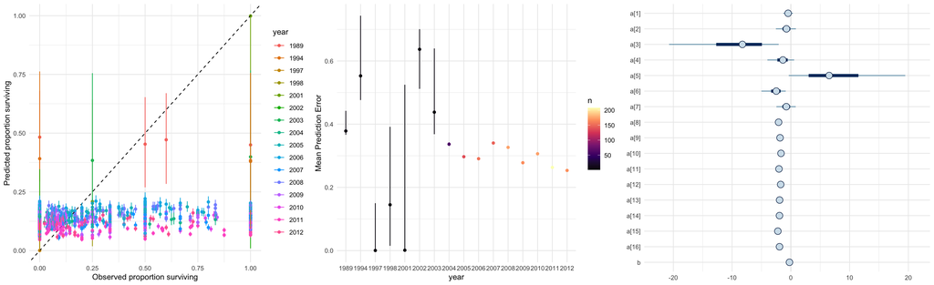

# Partial Pooling

```stan
data {
  // number of data points
    int <lower=0> n;

    // response
    // number of trees in each plot
    int <lower=1> n_trees [n];

    // number died
    int <lower=0> died [n];

    // predictors
    vector [n] temperature;

    // grouping
    int <lower=1> n_years;
    int <lower=1> year_id [n];
}
parameters {
    vector [n_years] a;
    real b;

    // average intercept by year
    real a_mu;
    // sd of intercepts
    real <lower=0> a_sig;
}
transformed parameters {
    vector [n] p;
    for(i in 1:n) {
        p[i] = inv_logit(a[year_id[i]] + b * temperature[i]);
    }
}
model {
    died ~ binomial(n_trees, p);
    // priors
    // hierarchical prior for a
    a ~ normal(a_mu, a_sig);
    b ~ normal(0, 5);

    a_mu ~ normal(0, 10);
    a_sig ~ gamma(0.1, 0.1);
}
generated quantities {
    int died_sim [n];
    for (i in 1:n) {
        died_sim[i] = binomial_rng(n_trees[i], p[i]);
    }
}
```

- We don’t really expect each year to be independent
  - it’s all one species, response to temperature should be similar
  - some years are better or worse than others
- Imagine instead there is a population of possible years, each with its own mortality
- This population has a true mean and a true variance
- The samples we’ve taken will come from that distribution
- This can tell us something about all possible years, not just these years

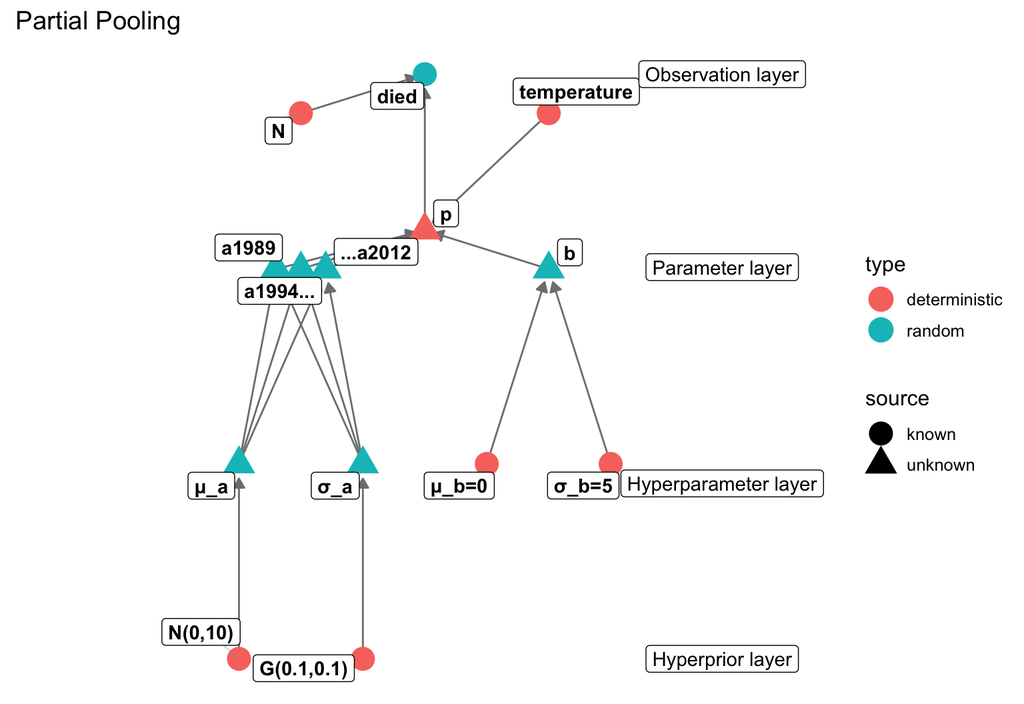

# Partial pooling is a compromise

- for a given group, we combine the information for this group with information from all groups
- balances precision and accuracy
- can be best approach for new groups
- weak/undersampled groups can “borrow strength” from others

```r
fit_h2pp = sampling(tsuga_h2pp, chains=4, iter=3000, refresh=0, data = standat)
```

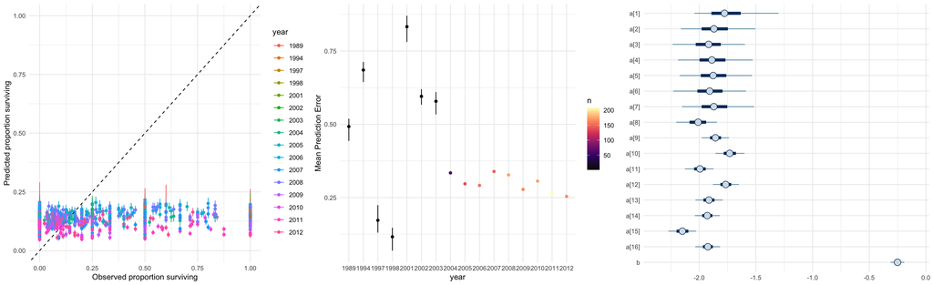

# Pooling comparison

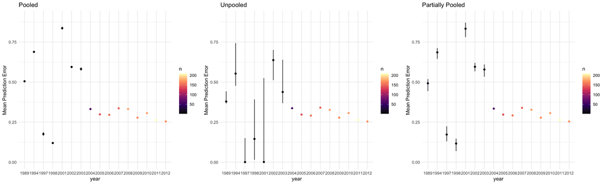

# Pooling comparison

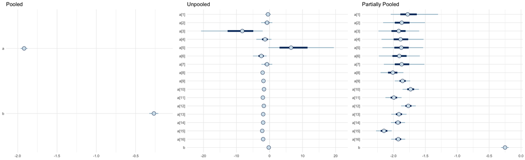

# When do we need hierarchical models?

- Repeated sampling within units (e.g., samples nested within plots/individuals)
- Inference at multiple levels of organisation
  - Covariates at multiple spatial scales
- Uneven sampling among units
- Accounting for nonindependence of samples
- Avoiding pre-averaging
  - Don’t: perform repeat samples on a unit, perform analysis on the average
  - Do: Build an HM accounting for variability within and among units
- A common category of HM is often called mixed modeling
  - All mixed models are hierarchical, not all hierarchical models are mixed models

# Designing hierarchical models in Stan

- You must specify data/objects at all levels
- Often we use an indexing variable to link observations to their group
- This variable **must** start at 1 and end at *n_groups*

```stan
data {
    // group-level objects
    int <lower=1> n_groups;
    int <lower=1, upper=n_groups> group_id [n];
}
parameters {
    vector [n_groups] a;

    // hyperparameters
    real a_mu;
    real a_sig;
}
transformed parameters {
    pr[i] = inv_logit(a[group_id[i]]);
}
model {
    a ~ normal(a_mu, a_sig);  // hierarchical prior for a
}
```

# Designing hierarchical models in Stan

- You must specify data/objects at all levels
- Often we use an indexing variable to link observations to their group
- This variable **must** start at 1 and end at *n_groups*
- Multiple non-nested groups are possible

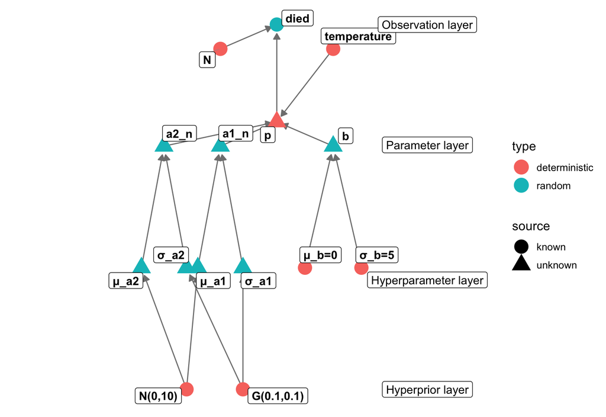

```stan
data {
    int n; // number of data points
    int died [n]
    int N[n];
    vector [n] temperature;

    // group-level objects
    int <lower=1> n_group1;
    int <lower=1, upper=n_group1> group1_id [n];

    int <lower=1> n_group2;
    int <lower=1, upper=n_group2> group2_id [n];
}
parameters {
    vector [n_group1] a1;
    vector [n_group2] a2;

    // hyperparameters
    real a1_mu;
    real <lower=0> a1_sig;
    real a2_mu;
    real <lower=0> a2_sig;
}
transformed parameters {
    vector [n] pr;
    for(i in 1:n)
        pr[i] = inv_logit(a1[group1_id[i]] + a2[group2_id[i]] + b*temperature[i]);
}
model {
    died ~ binomial(N, pr); // likelihood

    a1 ~ normal(a1_mu, a1_sig);  // hierarchical prior for a1
    a2 ~ normal(a2_mu, a2_sig);  // hierarchical prior for a2

    // hyperpriors
    a1_mu ~ normal(0,10)
    a2_mu ~ normal(0,10)
    a1_sig ~ gamma(0.1, 0.1);
    a2_sig ~ gamma(0.1, 0.1);
}
```

# Designing hierarchical models in Stan

- You must specify data/objects at all levels
- Often we use an indexing variable to link observations to their group
- This variable **must** start at 1 and end at *n_groups*
- Multiple non-nested groups are possible
- Nested groups add an additional hierarchical layer

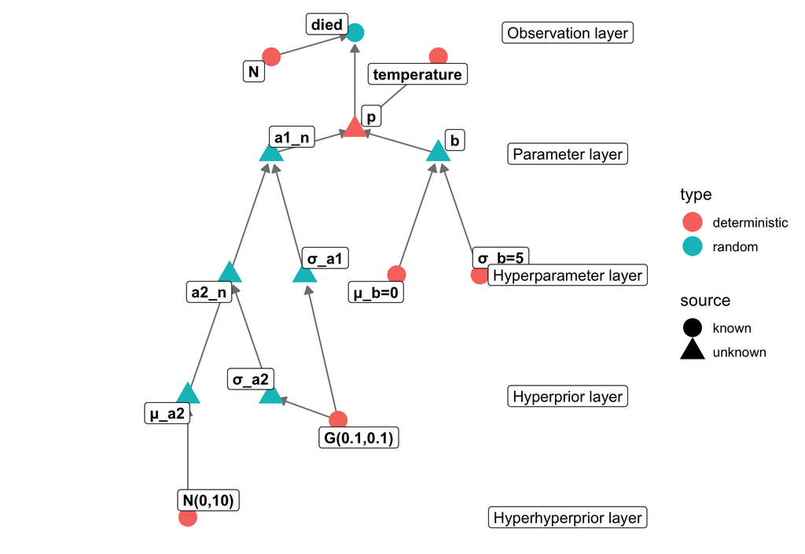

```stan
data {
    int n; // number of data points
    int died [n]
    int N[n];
    vector [n] temperature;

    // group-level objects
    int <lower=1> n_group1;
    int <lower=1, upper=n_group1> group1_id [n];

    int <lower=1> n_group2;
    int <lower=1, upper=n_group2> group2_id [n_group1];
}
parameters {
    vector [n_group1] a1;
    vector [n_group2] a2;

    // hyperparameters
    real <lower=0> a1_sig;
    real a2_mu;
    real <lower=0> a2_sig;
}
transformed parameters {
    vector [n] pr;
    for(i in 1:n)
        pr[i] = inv_logit(a1[group1_id[i]] + b*temperature[i]);
}
model {
    died ~ binomial(N, pr); // likelihood

    for(i in n_group1)
        a1 ~ normal(a2[i], a1_sig);  // hierarchical prior for a1
    // hyperpriors
    a2 ~ normal(a2_mu, a2_sig);  // hierarchical prior for a2
    a1_sig ~ gamma(0.1, 0.1);

    // hyperhyperprior
    a2_mu ~ normal(0,10)
}
```

# Posterior predictive distributions

- Note also that posterior prediction gets harder
- Do we want to predict new observations from a known group?
  - Same as before, can be easily done in Stan
- Or new observations from an unknown group?
  - Do in R
  - For each sim, draw values for the hyperparams (group-level effects)
  - Then simulate the individual observations

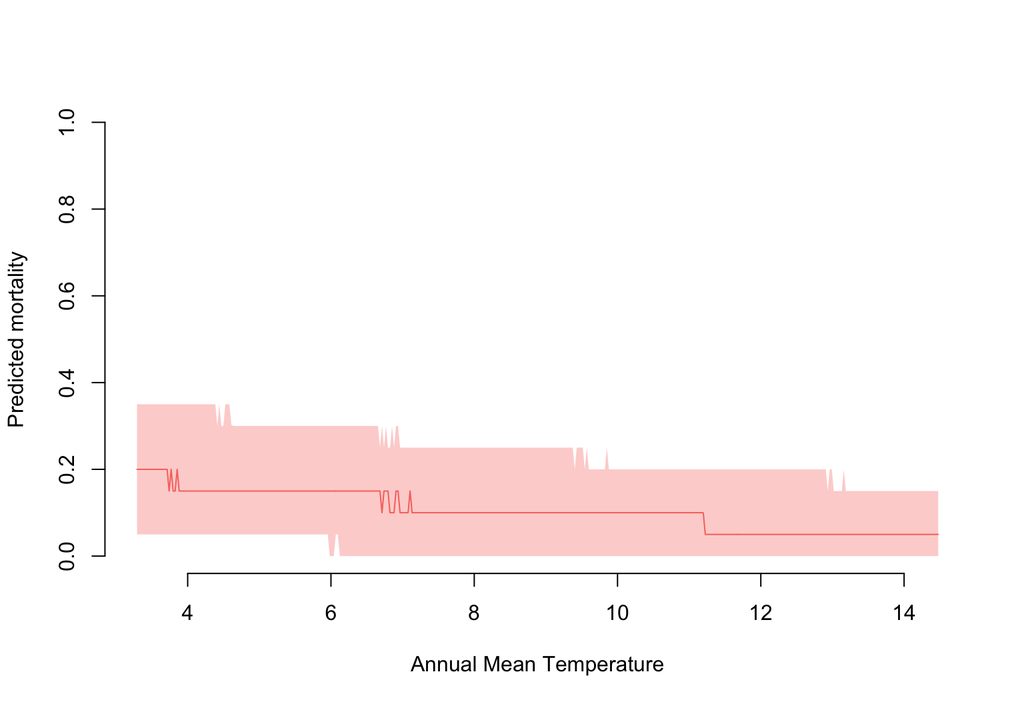

```r
sim1 = function(N, temperature, amu, asig, b) {
    a = rnorm(length(temperature), amu, asig)
    p = plogis(a + b*temperature)
    rbinom(length(temperature), N, p)
}
newx = seq(min(standat$temperature), max(standat$temperature), length.out=400)
pars = as.matrix(fit_h2pp, pars=c("a_mu", "a_sig", "b"))

# For our hypothetical, we need to decide how many trees we would see
# more trees means less sampling uncertainty
N = 20
sims = apply(pars, 1, function(x)
    sim1(N=N, temperature = newx, amu=x['a_mu'], asig = x['a_sig'], b = x['b']))
sim_qs = t(apply(sims, 1, quantile, c(0.5, 0.05, 0.95)))

## undo the scaling so we can see the plot on the original scale
newx_unscale = (newx * sd(tsuga$annual_mean_temp)) + mean(tsuga$annual_mean_temp)
plot(newx_unscale, sim_qs[,1]/N, type='l', bty='n', ylim = c(0,1),
     xlab = "Annual Mean Temperature", ylab = "Predicted mortality", col=cols[1])
polygon(c(newx_unscale, rev(newx_unscale)), c(sim_qs[,2], rev(sim_qs[,3]))/N,
        border=NA, col=paste0(cols[1], '55'))
```